# Multinomial regression

# Introduction

Multinomial regression is a type of regression analysis used to predict the outcome of a categorical dependent variable with more than two categories. It is an extension of logistic regression to the case where the dependent variable is nominal with more than two levels. The multinomial regression model generalizes logistic regression by allowing more than two discrete outcomes.

## Hypotheses of Multinomial Regression

The key hypotheses for multinomial regression are:

- Independence of Irrelevant Alternatives (IIA): This assumption states that the relative odds of choosing between any two alternatives are independent of the presence or characteristics of other alternatives.
- Linearity: The relationship between the independent variables and the log odds of the dependent variable is linear.
- No multicollinearity: The independent variables should not be too highly correlated with each other.

## Data and Packages

For this example, we will use the iris dataset from the datasets package. This dataset contains measurements of different characteristics of iris flowers and their species.

```r
# Load necessary packages
library(nnet)
library(datasets)
library(dplyr)
```

```r
library(ggplot2)
# Load the iris dataset
data(iris)
head(iris)
```

```
##   Sepal.Length Sepal.Width Petal.Length Petal.Width Species
## 1          5.1         3.5          1.4         0.2  setosa
## 2          4.9         3.0          1.4         0.2  setosa
## 3          4.7         3.2          1.3         0.2  setosa
## 4          4.6         3.1          1.5         0.2  setosa
## 5          5.0         3.6          1.4         0.2  setosa
## 6          5.4         3.9          1.7         0.4  setosa
```

## Data Preparation

The iris dataset contains 150 observations of iris flowers, with 4 continuous variables (Sepal.Length, Sepal.Width, Petal.Length, Petal.Width) and one categorical variable (Species). We will use Species as the dependent variable and the continuous variables as independent variables.

```r
# Convert Species to a factor
iris$Species <- as.factor(iris$Species)

# Check the structure of the dataset
str(iris)
```

```
## 'data.frame':    150 obs. of  5 variables:
##  $ Sepal.Length: num  5.1 4.9 4.7 4.6 5 5.4 4.6 5 4.4 4.9 ...
##  $ Sepal.Width : num  3.5 3 3.2 3.1 3.6 3.9 3.4 3.4 2.9 3.1 ...
##  $ Petal.Length: num  1.4 1.4 1.3 1.5 1.4 1.7 1.4 1.5 1.4 1.5 ...
##  $ Petal.Width : num  0.2 0.2 0.2 0.2 0.2 0.4 0.3 0.2 0.2 0.1 ...
##  $ Species     : Factor w/ 3 levels "setosa","versicolor",..: 1 1 1 1 1 1 1 1 1 1 ...
```

# Multinomial Regression Model

We will fit a multinomial regression model using the multinom function from the nnet package.

```r
# Fit the multinomial regression model
model <- multinom(Species ~ Sepal.Length + Sepal.Width + Petal.Length + Petal.Width, data = iris)
# Summary of the model
summary(model)
```

```
## Call:
## multinom(formula = Species ~ Sepal.Length + Sepal.Width + Petal.Length +
##     Petal.Width, data = iris)
##
## Coefficients:
##            (Intercept) Sepal.Length Sepal.Width Petal.Length Petal.Width
## versicolor    18.69037    -5.458424   -8.707401     14.24477   -3.097684
## virginica    -23.83628    -7.923634  -15.370769     23.65978   15.135301
##
## Std. Errors:
##            (Intercept) Sepal.Length Sepal.Width Petal.Length Petal.Width
## versicolor    34.97116     89.89215    157.0415     60.19170    45.48852
## virginica     35.76649     89.91153    157.1196     60.46753    45.93406
##
## Residual Deviance: 11.89973
## AIC: 31.89973
```

# Model Interpretation

The coefficients in the summary output represent the change in the log odds of the dependent variable being in one category versus the reference category for a one-unit change in the predictor variable.

# Predictions

We can use the model to make predictions on the training data.

```r
# Make predictions
predictions <- predict(model, iris)

# Create a confusion matrix to evaluate the model
table(Predicted = predictions, Actual = iris$Species)
```

```
##             Actual
## Predicted    setosa versicolor virginica
##   setosa         50          0         0
##   versicolor      0         49         1
##   virginica       0          1        49
```

# Model Accuracy

We can calculate the accuracy of the model by comparing the predicted species with the actual species.

```r
# Calculate accuracy
accuracy <- mean(predictions == iris$Species)
paste("Accuracy:", round(accuracy, 2))
```

```
## [1] "Accuracy: 0.99"
```

# Additional Example with Contingency Table

In this example, we’ll use a contingency table to perform multinomial regression. Let’s assume we have survey data on preferred modes of transport across different age groups.

## Data

Here’s a contingency table representing the survey data:

| Mode of Transport | Age Group 1 | Age Group 2 | Age Group 3 |
| --- | --- | --- | --- |
| Car | 40 | 30 | 20 |
| Bike | 20 | 25 | 25 |
| Public Transport | 15 | 20 | 30 |
| Walking | 25 | 25 | 25 |

We’ll convert this data into a format suitable for multinomial regression analysis.

```r
# Create a contingency table
transport_data <- data.frame(
  Transport = rep(c("Car", "Bike", "Public Transport", "Walking"), each = 3),
  AgeGroup = rep(c("Age Group 1", "Age Group 2", "Age Group 3"), times = 4),
  Count = c(40, 30, 20, 20, 25, 25, 15, 20, 30, 25, 25, 25)
)

# Convert AgeGroup and Transport to factors
transport_data$AgeGroup <- as.factor(transport_data$AgeGroup)
transport_data$Transport <- as.factor(transport_data$Transport)

head(transport_data)
```

```
##   Transport    AgeGroup Count
## 1       Car Age Group 1    40
## 2       Car Age Group 2    30
## 3       Car Age Group 3    20
## 4      Bike Age Group 1    20
## 5      Bike Age Group 2    25
## 6      Bike Age Group 3    25
```

# Multinomial Regression Model

We will fit a multinomial regression model to predict the mode of transport based on age group.

```r
# Fit the multinomial regression model
model_contingency <- multinom(Transport ~ AgeGroup, weights = Count, data = transport_data)
# Summary of the model
summary(model_contingency)
```

```
## Call:
## multinom(formula = Transport ~ AgeGroup, data = transport_data,
##     weights = Count)
##
## Coefficients:
##                  (Intercept) AgeGroupAge Group 2 AgeGroupAge Group 3
## Car                0.6931339         -0.51078107          -0.9162914
## Public Transport  -0.2877067          0.06459327           0.4700177
## Walking            0.2231142         -0.22308887          -0.2231198
##
## Std. Errors:
##                  (Intercept) AgeGroupAge Group 2 AgeGroupAge Group 3
## Car                0.2738596           0.3851402           0.4062009
## Public Transport   0.3415646           0.4546063           0.4358894
## Walking            0.2999995           0.4123111           0.4123098
##
## Residual Deviance: 814.3997
## AIC: 832.3997
```

# Exercises

To reinforce your understanding of multinomial regression, please complete the following exercises:

1. **Exercise 1**: Fit a multinomial regression model using only `Petal.Length` and `Petal.Width` as predictors. Summarize the model and interpret the coefficients.
2. **Exercise 2**: Calculate the confusion matrix and the accuracy of the new model from Exercise 1.
3. **Exercise 3**: Visualize the relationship between `Petal.Length` and `Petal.Width` with the predicted species from the new model using a scatter plot.
4. **Exercise 4**: Using the fitted model from the contingency table, predict the preferred mode of transport for each age group. Summarize the predictions and calculate the probabilities for each mode of transport within each age group.

**Show Solutions**

## Solutions

### Solution to Exercise 1

```r
# Fit the multinomial regression model with Petal.Length and Petal.Width
model_ex1 <- multinom(Species ~ Petal.Length + Petal.Width, data = iris)
# Summary of the model
summary(model_ex1)
```

```
## Call:
## multinom(formula = Species ~ Petal.Length + Petal.Width, data = iris)
##
## Coefficients:
##            (Intercept) Petal.Length Petal.Width
## versicolor   -22.79944      6.92122    7.878496
## virginica    -67.82521     12.64721   18.261016
##
## Std. Errors:
##            (Intercept) Petal.Length Petal.Width
## versicolor     44.3859     37.58715    81.00888
## virginica      46.3939     37.65702    81.09482
##
## Residual Deviance: 20.57901
## AIC: 32.57901
```

The coefficients in the summary output represent the change in the log odds of the dependent variable being in one category versus the reference category for a one-unit change in the predictor variable.

### Solution to Exercise 2

```r
# Make predictions
predictions_ex1 <- predict(model_ex1, iris)

# Create a confusion matrix to evaluate the model
confusion_matrix_ex1 <- table(Predicted = predictions_ex1, Actual = iris$Species)
confusion_matrix_ex1
```

```
##             Actual
## Predicted    setosa versicolor virginica
##   setosa         50          0         0
##   versicolor      0         47         3
##   virginica       0          3        47
```

```r
# Calculate accuracy
accuracy_ex1 <- mean(predictions_ex1 == iris$Species)
paste("Accuracy:", round(accuracy_ex1, 2))
```

```
## [1] "Accuracy: 0.96"
```

### Solution to Exercise 3

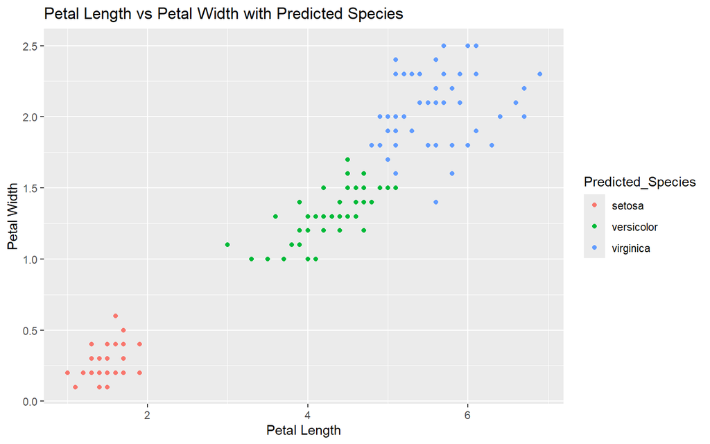

```r
# Visualize the relationship between Petal.Length and Petal.Width with predicted species
iris_with_preds <- iris
iris_with_preds$Predicted_Species <- predictions_ex1

ggplot(iris_with_preds, aes(x = Petal.Length, y = Petal.Width, color = Predicted_Species)) +
  geom_point() +
  labs(title = "Petal Length vs Petal Width with Predicted Species",
       x = "Petal Length",
       y = "Petal Width")
```

### Solution to Exercise 4

```r
# Make predictions
predictions_contingency <- predict(model_contingency, newdata = transport_data, type = "probs")

# Add the predicted probabilities to the original data
predicted_data <- cbind(transport_data, predictions_contingency)

# Display the updated data
predicted_data
```

```
##           Transport    AgeGroup Count      Bike       Car Public Transport
## 1               Car Age Group 1    40 0.2000033 0.4000012        0.1499988
## 2               Car Age Group 2    30 0.2499946 0.3000028        0.2000017
## 3               Car Age Group 3    20 0.2500018 0.1999987        0.2999990
## 4              Bike Age Group 1    20 0.2000033 0.4000012        0.1499988
## 5              Bike Age Group 2    25 0.2499946 0.3000028        0.2000017
## 6              Bike Age Group 3    25 0.2500018 0.1999987        0.2999990
## 7  Public Transport Age Group 1    15 0.2000033 0.4000012        0.1499988
## 8  Public Transport Age Group 2    20 0.2499946 0.3000028        0.2000017
## 9  Public Transport Age Group 3    30 0.2500018 0.1999987        0.2999990
## 10          Walking Age Group 1    25 0.2000033 0.4000012        0.1499988
## 11          Walking Age Group 2    25 0.2499946 0.3000028        0.2000017
## 12          Walking Age Group 3    25 0.2500018 0.1999987        0.2999990
##      Walking
## 1  0.2499968
## 2  0.2500009
## 3  0.2500004
## 4  0.2499968
## 5  0.2500009
## 6  0.2500004
## 7  0.2499968
## 8  0.2500009
## 9  0.2500004
## 10 0.2499968
## 11 0.2500009
## 12 0.2500004
```

```r
# Reshape the data for better readability
library(tidyr)
predicted_probs_long <- predicted_data %>%
  pivot_longer(cols = starts_with("Car"):starts_with("Walking"),
               names_to = "Predicted_Transport",
               values_to = "Probability") %>%
  select(AgeGroup, Predicted_Transport, Probability)

# Display the reshaped data
predicted_probs_long
```

```
## # A tibble: 36 × 3
##    AgeGroup    Predicted_Transport Probability
##    <fct>       <chr>                     <dbl>
##  1 Age Group 1 Car                       0.400
##  2 Age Group 1 Public Transport          0.150
##  3 Age Group 1 Walking                   0.250
##  4 Age Group 2 Car                       0.300
##  5 Age Group 2 Public Transport          0.200
##  6 Age Group 2 Walking                   0.250
##  7 Age Group 3 Car                       0.200
##  8 Age Group 3 Public Transport          0.300
##  9 Age Group 3 Walking                   0.250
## 10 Age Group 1 Car                       0.400
## # ℹ 26 more rows
```

# Conclusion

In this example, we demonstrated how to perform multinomial regression using the iris dataset. Multinomial regression is a powerful tool for modeling categorical outcomes with more than two levels. The nnet package in R provides a convenient function multinom to fit such models. The model we built showed reasonable accuracy in predicting the species of iris flowers based on their measurements.